# Week 2 Reproducible Research Project: Peer Assessment 1

C Barclay

26/06/2020

Before we start, lets load the necessary packages!

```r
# Load  packages
library(tidyverse)
```

```r
library(readr)
library(dplyr)
library(ggplot2)
```

PART 1. START

1. Loading and preprocessing the data.
2. Show any code that is needed to.

Load the data (i.e. read.csv())

Process/transform the data (if necessary) into a format suitable for your analysis.

```r
## Loading and preprocessing the data

# Coursera "activity.zip" file web location
fileUrl <-
  "https://d396qusza40orc.cloudfront.net/repdata%2Fdata%2Factivity.zip"

# Set and check working directory
wd <- setwd("C:/Downloads/Datasets")

# Download activity.zip" from webpage. (Remember to destfile to local file area!!!)

download.file(fileUrl, destfile = "C:/Downloads/Datasets/activity.zip",
              method = "curl")

# Unzip contents into R environment.
filesUnzip <-
  unzip(
    "activity.zip",
    files = NULL,
    list = TRUE,
    overwrite = TRUE,
    junkpaths = FALSE,
    exdir = wd,
    unzip = "internal",
    setTimes = FALSE
  )
```

UTILITY As the working directory will be reset when a chunk is finished running we need to specify the working directory using knitr.

```r
knitr::opts_knit$set(root.dir = 'C:/Downloads/Datasets')
```

PART 2. STEPS PER DAY

For this part of the assignment, you can ignore the missing values in the dataset.

1. Calculate the total number of steps taken per day.

If you do not understand the difference between a histogram and a barplot, research the difference between them.

2. Make a histogram of the total number of steps taken each day.
3. Calculate and report the mean and median of the total number of steps taken per day.

```r
## What is mean total number of steps taken per day? (Ignoring Na Values)

# Load activity.csv into R environment.
activity <- read.csv(filesUnzip$Name[1])

# Quick summary of file.
str(activity)
```

```
## 'data.frame':    17568 obs. of  3 variables:
##  $ steps   : int  NA NA NA NA NA NA NA NA NA NA ...
##  $ date    : Factor w/ 61 levels "2012-10-01","2012-10-02",..: 1 1 1 1 1 1 1 1 1 1 ...
##  $ interval: int  0 5 10 15 20 25 30 35 40 45 ...
```

```r
# Create the variable "activity_omit" with rows containing Na values removed.
activity_omit <- na.omit(activity)

# Tell user the number of rows with NA values in.
na_diff <- nrow(activity)-nrow(activity_omit)
print(paste("The total number of rows with NA is: ",na_diff))
```

```
## [1] "The total number of rows with NA is:  2304"
```

```r
# Group the number of steps by day and find total sum of steps per day; store in
# the variable "act_Days".
act_Days <- summarise(group_by(activity_omit,date),steps = sum(steps))

## Summary of the MEAN & MEDIAN number of steps per day.
summary(act_Days$steps)
```

```
##    Min. 1st Qu.  Median    Mean 3rd Qu.    Max.
##      41    8841   10765   10766   13294   21194
```

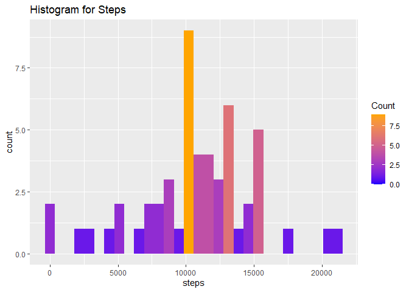

```r
# Create a Histogram using ggplot2.
ggplot(act_Days, aes(steps)) + geom_histogram(aes(fill=..count..)) + scale_fill_gradient("Count",low="blue", high="orange") + labs(title="Histogram for Steps")
```

PART 3. DAILY ACTIVITY

1. Make a time series plot (i.e. type = “l”) of the 5-minute interval (x-axis) and the average number of steps taken, averaged across all days (y-axis).
2. Which 5-minute interval, on average across all the days in the dataset, contains the maximum number of steps?

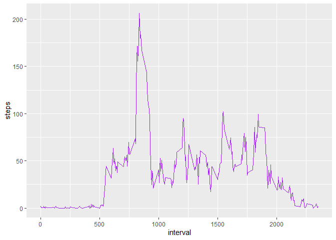

```r
## What is the average daily activity pattern?

# Group the column 'steps' by the column 'interval'. Aggregated 'steps' into
# averages within each 5 minute interval. Store as the variable "act_Interval".
act_Interval <- summarize(group_by(activity_omit, interval), steps=mean(steps))

# Create a Line Plot using ggplot2.
ggplot(act_Interval, aes(interval, steps)) + geom_line(colour ="purple")
```

```r
## Which 5-minute Interval, on average across all the days in the dataset,
## contains the maximum number of steps?

# Return the row in variable act_Interval for column steps, where steps is at
# maximum.
print(paste("Interval containing the most steps on average: ",act_Interval$interval[which.max(act_Interval$steps)]))
```

```
## [1] "Interval containing the most steps on average:  835"
```

```r
print(paste("Average steps for that interval: ",round(max(act_Interval$steps),digits=2)))
```

```
## [1] "Average steps for that interval:  206.17"
```

PART 4. DEALING WITH NAs

Note that there are a number of days/intervals where there are missing values (coded as NA). The presence of missing days may introduce bias into some calculations or summaries of the data.